# Self-Driving Car Engineer Nanodegree

## Project: Build a Traffic Sign Recognition Classifier

In this notebook, a template is provided for you to implement your functionality in stages, which is required to successfully complete this project. If additional code is required that cannot be included in the notebook, be sure that the Python code is successfully imported and included in your submission if necessary.

In addition to implementing code, there is a writeup to complete. The writeup should be completed in a separate file, which can be either a markdown file or a pdf document. There is a [write up template](https://github.com/udacity/CarND-Traffic-Sign-Classifier-Project/blob/master/writeup_template.md) that can be used to guide the writing process. Completing the code template and writeup template will cover all of the [rubric points](https://review.udacity.com/#!/rubrics/481/view) for this project.

The [rubric](https://review.udacity.com/#!/rubrics/481/view) contains "Stand Out Suggestions" for enhancing the project beyond the minimum requirements. The stand out suggestions are optional. If you decide to pursue the "stand out suggestions", you can include the code in this Ipython notebook and also discuss the results in the writeup file.

> **Note:** Code and Markdown cells can be executed using the **Shift + Enter** keyboard shortcut. In addition, Markdown cells can be edited by typically double-clicking the cell to enter edit mode.

## Step 0: Load The Data

```python
# Load pickled data
import pickle
import numpy as np
import pandas as pd

training_file = "../traffic-signs-data/train.p"
validation_file= "../traffic-signs-data/valid.p"
testing_file = "../traffic-signs-data/test.p"

train = None

with open(training_file, mode='rb') as f:
    train = pickle.load(f)
with open(validation_file, mode='rb') as f:
    valid = pickle.load(f)
with open(testing_file, mode='rb') as f:
    test = pickle.load(f)

X_train, y_train = train['features'], train['labels']
X_valid, y_valid = valid['features'], valid['labels']
X_test, y_test = test['features'], test['labels']


## To reload the processed dataset
with open("processed-shuffled-gray_train_test_valid.p", mode='rb') as f:
    X_train_, y_train_, X_test_, y_test_, X_valid_, y_valid_ = pickle.load(f)
```

## Step 1: Dataset Summary & Exploration

The pickled data is a dictionary with 4 key/value pairs:

- `'features'` is a 4D array containing raw pixel data of the traffic sign images, (num examples, width, height, channels).
- `'labels'` is a 1D array containing the label/class id of the traffic sign. The file `signnames.csv` contains id -> name mappings for each id.
- `'sizes'` is a list containing tuples, (width, height) representing the original width and height the image.
- `'coords'` is a list containing tuples, (x1, y1, x2, y2) representing coordinates of a bounding box around the sign in the image. **THESE COORDINATES ASSUME THE ORIGINAL IMAGE. THE PICKLED DATA CONTAINS RESIZED VERSIONS (32 by 32) OF THESE IMAGES**

Complete the basic data summary below. Use python, numpy and/or pandas methods to calculate the data summary rather than hard coding the results. For example, the [pandas shape method](http://pandas.pydata.org/pandas-docs/stable/generated/pandas.DataFrame.shape.html) might be useful for calculating some of the summary results.

### Provide a Basic Summary of the Data Set Using Python, Numpy and/or Pandas

```python
# Number of training examples
n_train = y_train.shape[0]

# Number of validation examples
n_validation = y_valid.shape[0]

# Number of testing examples.
n_test = y_test.shape[0]

# the shape of an traffic sign image
image_shape = X_train[0].shape

# unique classes/labels there are in the dataset.
n_classes = len(np.unique(y_test))

print("Number of training examples =", n_train)
print("Number of testing examples =", n_test)
print("Number of validation examples =", n_validation)
print("Image data shape =", image_shape)
print("Number of classes =", n_classes)
```

```
Number of training examples = 34799
Number of testing examples = 12630
Number of validation examples = 4410
Image data shape = (32, 32, 3)
Number of classes = 43
```

### Include an exploratory visualization of the dataset

Visualize the German Traffic Signs Dataset using the pickled file(s). This is open ended, suggestions include: plotting traffic sign images, plotting the count of each sign, etc.

The [Matplotlib](http://matplotlib.org/) [examples](http://matplotlib.org/examples/index.html) and [gallery](http://matplotlib.org/gallery.html) pages are a great resource for doing visualizations in Python.

**NOTE:** It's recommended you start with something simple first. If you wish to do more, come back to it after you've completed the rest of the sections. It can be interesting to look at the distribution of classes in the training, validation and test set. Is the distribution the same? Are there more examples of some classes than others?

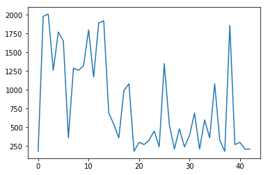

```python
import matplotlib.pyplot as plt

# Visualizations will be shown in the notebook.
%matplotlib inline

### Plot the number of examples in each class

# Get the classes and their counts
unique, counts = np.unique(y_train, return_counts=True)

# plot the number of samples in each class
plt.plot(unique, counts)
```

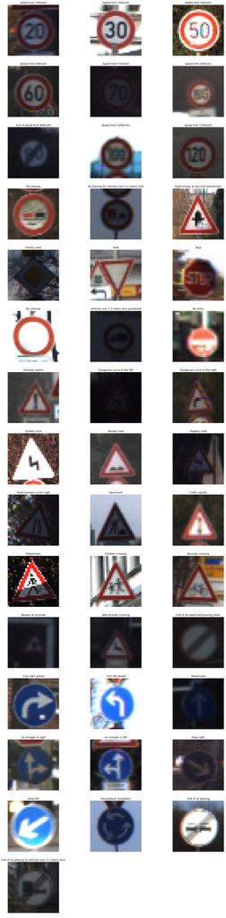

```python
### Plot an example from each class

# Load the label of each class
labels_df = pd.read_csv('signnames.csv')
labels = list(labels_df['SignName'])

# call the plot to plot the images
plt.figure(figsize=(20, 80))

# number of rows of the plot grid
r = int(np.ceil(len(unique) / 3))

# loop through each class
for i in unique:

    # create the subplot to plot the example
    plt.subplot(r, 3, i+1)

    # get the index of an example belonging to the class
    img_index = np.random.choice(np.where(y_test == i)[0])

    # plot the example
    plt.imshow(X_test[img_index])

    # plot the label for the class
    plt.title(labels[i])

    plt.axis('off')
```

## Step 2: Design and Test a Model Architecture

Design and implement a deep learning model that learns to recognize traffic signs. Train and test your model on the [German Traffic Sign Dataset](http://benchmark.ini.rub.de/?section=gtsrb&subsection=dataset).

The LeNet-5 implementation shown in the classroom at the end of the CNN lesson is a solid starting point. You'll have to change the number of classes and possibly the preprocessing, but aside from that it's plug and play!

With the LeNet-5 solution from the lecture, you should expect a validation set accuracy of about 0.89. To meet specifications, the validation set accuracy will need to be at least 0.93. It is possible to get an even higher accuracy, but 0.93 is the minimum for a successful project submission.

There are various aspects to consider when thinking about this problem:

- Neural network architecture (is the network over or underfitting?)
- Play around preprocessing techniques (normalization, rgb to grayscale, etc)
- Number of examples per label (some have more than others).
- Generate fake data.

Here is an example of a [published baseline model on this problem](http://yann.lecun.com/exdb/publis/pdf/sermanet-ijcnn-11.pdf). It's not required to be familiar with the approach used in the paper but, it's good practice to try to read papers like these.

### Pre-process the Data Set (normalization, grayscale, etc.)

Minimally, the image data should be normalized so that the data has mean zero and equal variance. For image data, `(pixel - 128)/ 128` is a quick way to approximately normalize the data and can be used in this project.

Other pre-processing steps are optional. You can try different techniques to see if it improves performance.

Use the code cell (or multiple code cells, if necessary) to implement the first step of your project.

```python
### Function definitions to perform the preprocessing

from PIL import Image # Image processing Library
from PIL import ImageOps # Module for basic image manipulation
import random as r # to select samples randomly for processing
import time # time the processing duration of the dataset

# function to choose random integer from a given array
rd = r.randint

# function to find coefficients of the transformation matrix to do the perspective transform
def find_coeffs(pa, pb):
    matrix = []
    for p1, p2 in zip(pa, pb):
        matrix.append([p1[0], p1[1], 1, 0, 0, 0, -p2[0]*p1[0], -p2[0]*p1[1]])
        matrix.append([0, 0, 0, p1[0], p1[1], 1, -p2[1]*p1[0], -p2[1]*p1[1]])

    A = np.matrix(matrix, dtype=np.float)
    B = np.array(pb).reshape(8)

    res = np.dot(np.linalg.inv(A.T * A) * A.T, B)
    return np.array(res).reshape(8)

# function to find dimensions to crop the sheared image
def get_crop_dims(img, orig):
    ow, oh = orig.size
    w, h = img.size
    cx = w/2
    cy = h/2
    l = cx - ow/2
    r = cx + ow/2
    u = cy - oh/2
    d = cy + oh/2
    crop_tuple = (l, u, r, d)
    return crop_tuple

# funtion to shear transform the image
def shear(im):
    width, height = im.size
    m = r.randrange(-25, 25, 1)/100.
    xshift = abs(m) * width
    new_width = width + int(round(xshift))
    shear_vec = (1, m, -xshift if m > 0 else 0, 0, 1, 0)
    imt = im.transform((new_width, height), Image.AFFINE,
            shear_vec, Image.BICUBIC)
    imt = imt.crop(get_crop_dims(imt,im))
#     print('Image transformed applying Shear vector ', shear_vec)
    return imt

# function to do perspective transformation to an image
def perspective_distort(img):

    width, height = img.size
    del_width = int(width * 0.25)
    del_height = int(height * 0.25)

    rx = (width - del_width, width)
    lx = (0, del_width)
    ty = (0, del_height)
    by = (height - del_height, height)

    pa = [(rd(*lx), rd(*ty)), (rd(*rx), rd(*ty)), (rd(*lx), rd(*by)), (rd(*rx), rd(*by))]
    pb = [(rd(*lx), rd(*ty)), (rd(*rx), rd(*ty)), (rd(*lx), rd(*by)), (rd(*rx), rd(*by))]

    coeffs = find_coeffs(pa, pb)

    imgp = img.transform((width, height), Image.PERSPECTIVE, coeffs,
            Image.BICUBIC)
#     print('Image transformed applying Perspective Distortion with coefficient matrix ', coeffs)
    return imgp

# function to do a random number of rotation, shearing and perspective transformation to the image
def rand_transform(img, X_train, y_train):

    for i in range(r.randrange(2, 5, 1)):
        angle = r.randrange(-30, 30, 1)
        imgrot = img.rotate(angle)
        imgrot = np.array(imgrot)
        X_train = np.concatenate((X_train, imgrot.reshape((1,) + imgrot.shape + (1,))))
        y_train = np.concatenate((y_train, y_train[-1].reshape((1,) + y_train[-1].shape)))
#         print('Image Rotated at angle ', angle)

    for i in range(r.randrange(2, 5, 1)):
        imgsh = shear(img)
        imgsh = np.array(imgsh)
        X_train = np.concatenate((X_train, imgsh.reshape((1,) + imgsh.shape + (1,))))
        y_train = np.concatenate((y_train, y_train[-1].reshape((1,) + y_train[-1].shape)))

    for i in range(r.randrange(2, 6, 1)):
        imgp = perspective_distort(img)
        imgp = np.array(imgp)
        X_train = np.concatenate((X_train, imgp.reshape((1,) + imgp.shape + (1,))))
        y_train = np.concatenate((y_train, y_train[-1].reshape((1,) + y_train[-1].shape)))

    return X_train, y_train
```

```python
from scipy.stats import norm

# make sure the X and y have same amount of samples
assert len(y_train) == len(X_train)

# create empty arrays of 0 length for x and y of the augmented dataset
# as placeholder to append the original and transformed samples to
X_train_aug = np.empty( shape=((0,) + (X_train[0].shape[0], X_train[0].shape[1], 1)), dtype=X_train.dtype )
y_train_aug = np.empty( shape=((0,) + y_train[0].shape), dtype=y_train.dtype )

# start timer
start_time = time.time()

# loop through each image in the training set
for _ in range(len(X_train)):

    # since there are many traning samples, only print at every 500 to indicate progress
    if _ % 500 == 0: print('Processing Image {}....'.format(_))

    # Asssign probability of apllying various transformations to the ímage
    # based on its frequency in orignal dataset to even out the distribution of classes
    count = counts[y_train[_]]
    prob = norm.cdf(-1 + 2*((count - counts.min())/(counts.max() - counts.min())), loc=-0.6, scale=.4)

    # convert to Pillow Imange format to apply tranformations
    img = Image.fromarray(X_train[_], 'RGB')

    # convert image to grayscale and append to the augmented dataset
    imgt = img.convert("L")
    imgmat = np.array(imgt)
    X_train_aug = np.concatenate((X_train_aug, imgmat.reshape((1,) + imgmat.shape + (1,))))
    y_train_aug = np.concatenate((y_train_aug, y_train[_].reshape((1,) + y_train[_].shape)))

    # randomly apply rotation, shear and perspective distortion transformations
    if r.choices([True, False], cum_weights=[1-prob, prob])[0]:
        X_train_aug, y_train_aug = rand_transform(imgt, X_train_aug, y_train_aug)


# calculate the total time it took to go through the loop and create the augmented dataset
total_time = format(time.time() - start_time)

# print the number of samples after augmentation
print("Augmented {} samples into {}.".format(len(y_train), len(y_train_aug)))
# print the total processing time
print("Total time: ", str(total_time), "seconds.")
```

[output not shown]

[output cut: 17 more lines]

[output not shown]

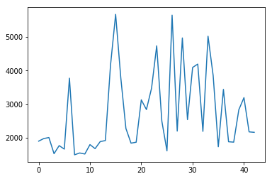

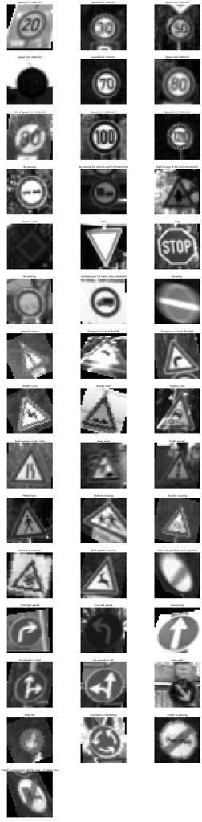

```python
### Visualize Augmented dataset

# Get the classes and their counts
u, c  = np.unique(y_train_aug, return_counts=True)

# plot the number of samples in each class
plt.figure()
plt.plot(u, c)

### plot example from each class in the augmented dataset

# call the plot to plot the images
plt.figure(figsize=(20, 80))

# number of rows of the plot grid
r = int(np.ceil(len(u) / 3))

# loop through each class
for i in u:

    # create the subplot to plot the example
    plt.subplot(r, 3, i+1)

    # get the index of an example belonging to the class
    img_index = np.random.choice(np.where(y_train_aug == i)[0])

    # plot the example
    image = X_train_aug[img_index]
    plt.imshow(image[...,0], cmap='gray')

    # plot the label for the class
    plt.title(labels[i])

    # disable axes
    plt.axis('off')
```

```python
### Converting test and validation sets to grayscale

assert len(y_valid) == len(X_valid)
assert len(y_test) == len(X_test)

X_valid_aug = np.empty( shape=((0,) + (X_valid[0].shape[0], X_valid[0].shape[1], 1)), dtype=X_valid.dtype )
y_valid_aug = np.empty( shape=((0,) + y_valid[0].shape), dtype=y_valid.dtype )
X_test_aug = np.empty( shape=((0,) + (X_test[0].shape[0], X_test[0].shape[1], 1)), dtype=X_test.dtype )
y_test_aug = np.empty( shape=((0,) + y_test[0].shape), dtype=y_test.dtype )

# loop to convert validation set
for _ in range(len(X_valid)):

    if _ % 500 == 0: print('Processing Validation Image {}....'.format(_))

    # convert to Pillow Imange format to apply tranformations
    img = Image.fromarray(X_valid[_], 'RGB')

    # convert image to grayscale and append to the augmented dataset
    imgt = img.convert("L")
    imgmat = np.array(imgt)
    X_valid_aug = np.concatenate((X_valid_aug, imgmat.reshape((1,) + imgmat.shape + (1,))))
    y_valid_aug = np.concatenate((y_valid_aug, y_valid[_].reshape((1,) + y_valid[_].shape)))

# loop to cenvert test set
for _ in range(len(X_test)):

    if _ % 500 == 0: print('Processing Test Image {}....'.format(_))

    # convert to Pillow Imange format to apply tranformations
    img = Image.fromarray(X_test[_], 'RGB')

    # convert image to grayscale and append to the augmented dataset
    imgt = img.convert("L")
    imgmat = np.array(imgt)
    X_test_aug = np.concatenate((X_test_aug, imgmat.reshape((1,) + imgmat.shape + (1,))))
    y_test_aug = np.concatenate((y_test_aug, y_test[_].reshape((1,) + y_test[_].shape)))

print("Test and Validation sets converted to grayscale")
```

[output not shown]

```python
### Shuffle the datasets

from sklearn.utils import shuffle

# Use _ postfix to indicate processed dataset to differntiate from orginal and
# to keep uniformity of nomenclature by removing the ambigious _aug postfix

X_train_, y_train_ = shuffle(X_train_aug, y_train_aug)
X_test_, y_test_ = shuffle(X_test_aug, y_test_aug)
X_valid_, y_valid_ = shuffle(X_valid_aug, y_valid_aug)
```

```python
### Save dataset to disk for direct loading in future

with open('processed-shuffled-gray_train_test_valid.p', mode='wb') as f:
    pickle.dump([X_train_, y_train_, X_test_, y_test_, X_valid_, y_valid_], f, protocol=2)

print('done!')
```

```
done!
```

### Model Architecture

```python
import tensorflow as tf
from tensorflow.contrib.layers import flatten

def LeNet(x):
    # Arguments used for tf.truncated_normal, randomly defines variables for the weights and biases for each layer
    mu = 0
    sigma = 0.1

    ## RESIDUAL BLOCK 1

    # Layer 1: Convolutional. Input = 32x32x3. Output = 28x28x6.
    conv1_W = tf.Variable(tf.truncated_normal(shape=(5, 5, 1, 6), mean = mu, stddev = sigma))
    conv1_b = tf.Variable(tf.zeros(6))
    conv1   = tf.nn.conv2d(x, conv1_W, strides=[1, 1, 1, 1], padding='VALID') + conv1_b

    # Activation.
    conv1 = tf.nn.relu(conv1)

    # Layer 2: Convolutional. Output = 24x24x16
    conv2_W = tf.Variable(tf.truncated_normal(shape=(5, 5, 6, 16), mean = mu, stddev = sigma))
    conv2_b = tf.Variable(tf.zeros(16))
    conv2   = tf.nn.conv2d(conv1, conv2_W, strides=[1, 1, 1, 1], padding='VALID') + conv2_b

    # Activation.
    conv2 = tf.nn.relu(conv2)

    # Padding as linear projection for residual block
    padding = tf.constant([[0, 0,], [2, 2], [2, 2,], [0, 0]])
    conv2 = tf.pad(conv2, padding, "SYMMETRIC") # 28x28x16

    # Pooling. Input = 28x28x22. Output = 14x14x22
    res1 = tf.nn.max_pool(tf.concat([conv2, conv1], 3), ksize=[1, 2, 2, 1], strides=[1, 2, 2, 1], padding='VALID')

    ## RESIDUAL BLOCK 2

    # Layer 3: Convolutional. Output = 12x12x32
    conv3_W = tf.Variable(tf.truncated_normal(shape=(3, 3, 22, 32), mean = mu, stddev = sigma))
    conv3_b = tf.Variable(tf.zeros(32))
    conv3   = tf.nn.conv2d(res1, conv3_W, strides=[1, 1, 1, 1], padding='VALID') + conv3_b

    # Activation.
    conv3 = tf.nn.relu(conv3)

    # Layer 4: Convolutional. Output = 10x10x32
    conv4_W = tf.Variable(tf.truncated_normal(shape=(3, 3, 32, 32), mean = mu, stddev = sigma))
    conv4_b = tf.Variable(tf.zeros(32))
    conv4   = tf.nn.conv2d(conv3, conv4_W, strides=[1, 1, 1, 1], padding='VALID') + conv4_b

    # Activation.
    conv4 = tf.nn.relu(conv4)

    # Padding as linear projection for residual block
    padding = tf.constant([[0, 0,], [1, 1], [1, 1,], [0, 0]])
    conv4 = tf.pad(conv4, padding, "SYMMETRIC") # 12x12x32

    # Pooling. Input = 12x12x64. Output = 6x6x64
    res2 = tf.nn.max_pool(tf.concat([conv4, conv3], 3), ksize=[1, 2, 2, 1], strides=[1, 2, 2, 1], padding='VALID')

    ## FLATTEN. Input = 6x6x64. Output = 2304

    fc0   = flatten(res2)

    # Layer 5: Fully Connected. Input = 400. Output = 120. 512
    fc1_W = tf.Variable(tf.truncated_normal(shape=(2304, 1024), mean = mu, stddev = sigma))
    fc1_b = tf.Variable(tf.zeros(1024))
    fc1   = tf.matmul(fc0, fc1_W) + fc1_b

    # Activation.
    fc1    = tf.nn.relu(fc1)

    # Layer 6: Fully Connected. Input = 120. Output = 84. 128
    fc2_W  = tf.Variable(tf.truncated_normal(shape=(1024, 512), mean = mu, stddev = sigma))
    fc2_b  = tf.Variable(tf.zeros(512))
    fc2    = tf.matmul(fc1, fc2_W) + fc2_b

    # SOLUTION: Activation.
    fc2    = tf.nn.relu(fc2)

    # Layer 7: Fully Connected. Input = 120. Output = 84. 128
    fc4_W  = tf.Variable(tf.truncated_normal(shape=(512, 128), mean = mu, stddev = sigma))
    fc4_b  = tf.Variable(tf.zeros(128))
    fc4    = tf.matmul(fc2, fc4_W) + fc4_b

    # Activation.
    fc4    = tf.nn.relu(fc4)

    # Layer 8: Fully Connected. Input = 84. Output = 43.
    fc3_W  = tf.Variable(tf.truncated_normal(shape=(128, 43), mean = mu, stddev = sigma))
    fc3_b  = tf.Variable(tf.zeros(43))
    logits = tf.matmul(fc4, fc3_W) + fc3_b

    return logits
```

### Train, Validate and Test the Model

A validation set can be used to assess how well the model is performing. A low accuracy on the training and validation sets imply underfitting. A high accuracy on the training set but low accuracy on the validation set implies overfitting.

```python
# Defining training parameters: Epocs and batch size

EPOCHS = 200
BATCH_SIZE = 128

# Creating tensorflow placeholders for the input x, label y and output with One-Hot Embedding one_hot_y variables

x = tf.placeholder(tf.float32, (None, 32, 32, 1))
y = tf.placeholder(tf.int32, (None))
one_hot_y = tf.one_hot(y, 43)
```

#### Training Pipeline

```python
# learning rate
rate = 0.0005

# initialize model graph
logits = LeNet(x)

# calculate cross entropy error between labels and predictions
cross_entropy = tf.nn.softmax_cross_entropy_with_logits_v2(labels=one_hot_y, logits=logits)

# calculate mean error
loss_operation = tf.reduce_mean(cross_entropy)

# optimizer function used for training
optimizer = tf.train.AdamOptimizer(learning_rate = rate)

# call operator function on the optimizer
training_operation = optimizer.minimize(loss_operation)
```

#### Evaluation Pipeline

```python
# evaluate if the model prediction is correct against the traning label
correct_prediction = tf.equal(tf.argmax(logits, 1), tf.argmax(one_hot_y, 1))

# calculate model accuracy
accuracy_operation = tf.reduce_mean(tf.cast(correct_prediction, tf.float32))

# tensorflow saver module to load and restore the trained model to/from disk
saver = tf.train.Saver()

# function to batch-wise calculate the total accuracy of the model on input test dataset
def evaluate(X_data, y_data):
    num_examples = len(X_data)
    total_accuracy = 0
    sess = tf.get_default_session()
    for offset in range(0, num_examples, BATCH_SIZE):
        batch_x, batch_y = X_data[offset:offset+BATCH_SIZE], y_data[offset:offset+BATCH_SIZE]
        accuracy = sess.run(accuracy_operation, feed_dict={x: batch_x, y: batch_y})
        total_accuracy += (accuracy * len(batch_x))
    return total_accuracy / num_examples
```

#### Train the Model

```python
### Model traning

# invoke tensorflow session
with tf.Session() as sess:

    # initialize variables
    sess.run(tf.global_variables_initializer())

    # number of tranining samples
    num_examples = len(X_train_)

    print("Training...")
    print()

    ## Traning Loop
    for i in range(EPOCHS):

        # batch-wise traning loop
        for offset in range(0, num_examples, BATCH_SIZE):

            # last index of a batch
            end = offset + BATCH_SIZE

            # batch extraction
            batch_x, batch_y = X_train_[offset:end], y_train_[offset:end]

            # run tensorflow graph on the batch for training
            sess.run(training_operation, feed_dict={x: batch_x, y: batch_y})

        # calculate accuracy on the validation set for the epoxh
        validation_accuracy = evaluate(X_valid_, y_valid_)

        # print epoch summary
        print("EPOCH {} ...".format(i+1))
        print("Validation Accuracy = {:.3f}".format(validation_accuracy))
        print()

    # save model to disk
    saver.save(sess, './lenet')
    print("Model saved")
```

```
Training...

EPOCH 1 ...
Validation Accuracy = 0.076

EPOCH 2 ...
Validation Accuracy = 0.419

EPOCH 3 ...
Validation Accuracy = 0.698

EPOCH 4 ...
Validation Accuracy = 0.813

EPOCH 5 ...
Validation Accuracy = 0.860

EPOCH 6 ...
Validation Accuracy = 0.883

EPOCH 7 ...
Validation Accuracy = 0.897

EPOCH 8 ...
Validation Accuracy = 0.904

EPOCH 9 ...
Validation Accuracy = 0.911

EPOCH 10 ...
Validation Accuracy = 0.929

EPOCH 11 ...
Validation Accuracy = 0.932

EPOCH 12 ...
Validation Accuracy = 0.947

EPOCH 13 ...
Validation Accuracy = 0.954
```

[output cut: 548 more lines]

```
Validation Accuracy = 0.973

EPOCH 197 ...
Validation Accuracy = 0.966

EPOCH 198 ...
Validation Accuracy = 0.983

EPOCH 199 ...
Validation Accuracy = 0.976

EPOCH 200 ...
Validation Accuracy = 0.980

Model saved
```

#### Evaluate the Model

```python
with tf.Session() as sess:

    # restore saved model from disk for evaluation on the test set
    saver.restore(sess, "./lenet")

    # calculate the accuracy of the model on test set anf print results
    test_accuracy = evaluate(X_test_, y_test_)
    print("Test Accuracy = {:.3f}".format(test_accuracy))
```

```
INFO:tensorflow:Restoring parameters from ./lenet
Test Accuracy = 0.945
```

## Step 3: Test a Model on New Images

To give yourself more insight into how your model is working, download at least five pictures of German traffic signs from the web and use your model to predict the traffic sign type.

You may find `signnames.csv` useful as it contains mappings from the class id (integer) to the actual sign name.

### Load and Output the Images

```
Shape of image set:  (12, 32, 32, 1)
Shape of label set:  (12,)
```

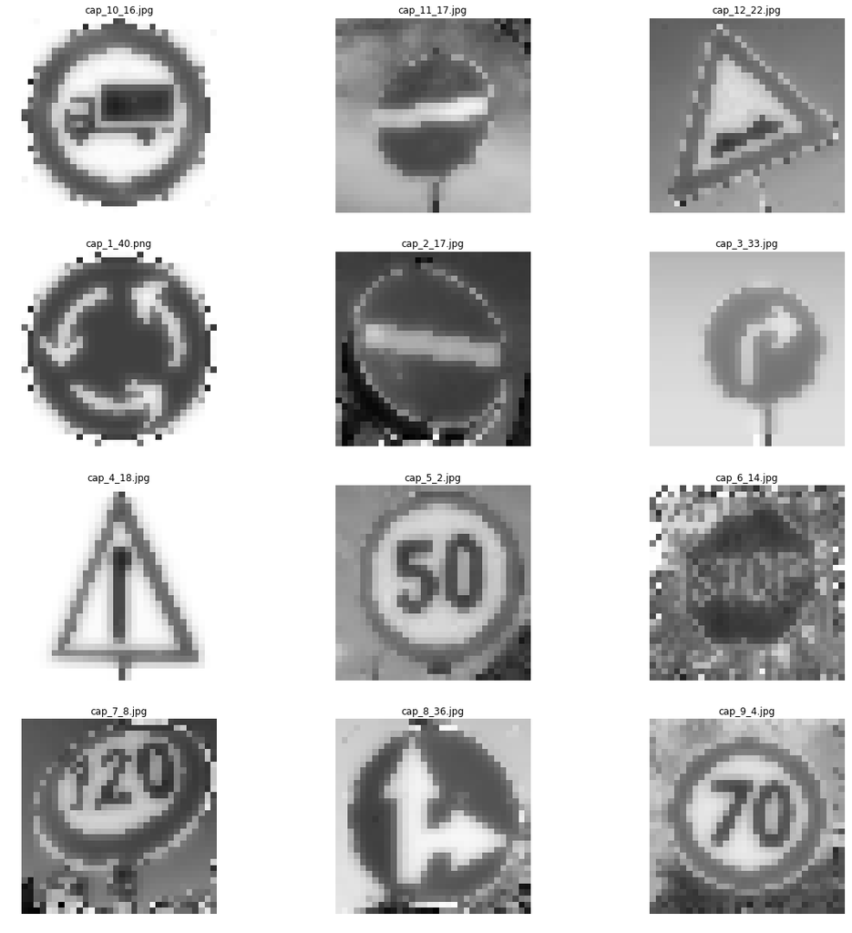

```python
### Load the images and plot them here.

from PIL import ImageFilter # module for basic image filters

# call the plot to plot the images
plt.figure(figsize=(20, 80))

# number of rows of the plot grid
row = int(np.ceil(len(unique) / 3))

# store image file names into array using Bash Syntax
images = !ls captures

# create placeholder arrays, empty with 0 length, to append the image and label data to
X_capture = np.empty( shape=((0,) + X_train_[0].shape), dtype=X_train_.dtype )
y_capture = np.empty( shape=((0,) + y_train_[0].shape), dtype=y_train_.dtype )

# loop through the images to plot and add to X and y arrays for testing
for i in range(len(images)):

    # create the subplot to plot the example
    plt.subplot(row, 3, i+1)

    # open the image in Pillow format
    img = Image.open('captures/' + images[i])

    # convert to grayscale as our model is only traning on gray
    img = img.convert("L")

    # resize the images into 32x32 as our model input
    img = img.resize((32,32))

    # resizing outputs a very sharp image, so apply standard smoothing
    img = img.filter(ImageFilter.SMOOTH_MORE)

    # plot the example
    plt.imshow(img)

    # plot the label for the class
    plt.title(images[i])

    # remove axis
    plt.axis('off')

    # Extract class label from the image title
    label = images[i][:-4].split('_')[-1]

    # Add the image and its label to X and y arrays for testing the images
    X_capture = np.concatenate((X_capture, np.array(img).reshape((1,) + X_train_[0].shape)))
    y_capture = np.concatenate((y_capture, np.array(label).reshape((1,) + y_train_[0].shape)))

# print the test set summary
print("Shape of image set: ", X_capture.shape)
print("Shape of label set: ", y_capture.shape)
```

### Predict the Sign Type for Each Image

```
INFO:tensorflow:Restoring parameters from ./lenet
```

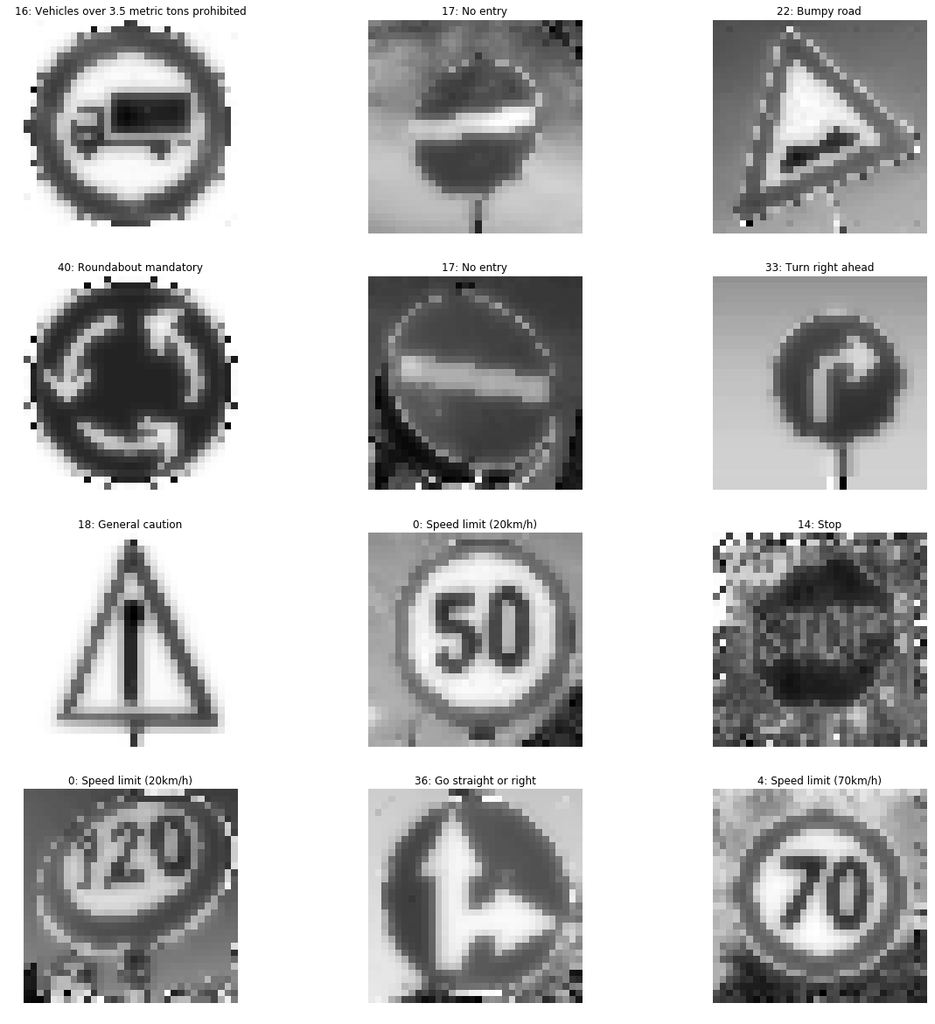

```python
### Run the predictions here and use the model to output the prediction for each image.

# initialize tensorflow session
with tf.Session() as sess:

    # load the traning model from disk
    saver.restore(sess, "./lenet")

    # run the model on test set and output just the top predicted classes for each sample
    argmax = sess.run(tf.argmax(logits,1), feed_dict={x: X_capture})

# plot grid initialization
plt.figure(figsize=(20, 80))

# number of rows of the plot grid
row = int(np.ceil(len(unique) / 3))

# loop through the images to plot and add to X and y arrays for testing
for i in range(len(X_capture)):

    # create the subplot to plot the sample
    plt.subplot(row, 3, i+1)

    # plot the sample
    plt.imshow(X_capture[i][...,0], cmap='gray')

    # plot the predicted class and its label
    plt.title(str(argmax[i]) + ': ' + labels[argmax[i]])

    # remove axis
    plt.axis('off')
```

### Analyze Performance

```python
### Calculate the accuracy for the new images.

# using the same function as one used for test set for the new images

with tf.Session() as sess:
    saver.restore(sess, "./lenet")

    capture_accuracy = evaluate(X_capture, y_capture)
    print("Accuracy = {:.3f}".format(capture_accuracy))
```

```
INFO:tensorflow:Restoring parameters from ./lenet
Accuracy = 0.833
```

### Output Top 5 Softmax Probabilities For Each Image Found on the Web

For each of the new images, print out the model's softmax probabilities to show the **certainty** of the model's predictions (limit the output to the top 5 probabilities for each image). [`tf.nn.top_k`](https://www.tensorflow.org/versions/r0.12/api_docs/python/nn.html#top_k) could prove helpful here.

The example below demonstrates how tf.nn.top_k can be used to find the top k predictions for each image.

`tf.nn.top_k` will return the values and indices (class ids) of the top k predictions. So if k=3, for each sign, it'll return the 3 largest probabilities (out of a possible 43) and the correspoding class ids.

Take this numpy array as an example. The values in the array represent predictions. The array contains softmax probabilities for five candidate images with six possible classes. `tf.nn.top_k` is used to choose the three classes with the highest probability:

```
# (5, 6) array
a = np.array([[ 0.24879643,  0.07032244,  0.12641572,  0.34763842,  0.07893497,
         0.12789202],
       [ 0.28086119,  0.27569815,  0.08594638,  0.0178669 ,  0.18063401,
         0.15899337],
       [ 0.26076848,  0.23664738,  0.08020603,  0.07001922,  0.1134371 ,
         0.23892179],
       [ 0.11943333,  0.29198961,  0.02605103,  0.26234032,  0.1351348 ,
         0.16505091],
       [ 0.09561176,  0.34396535,  0.0643941 ,  0.16240774,  0.24206137,
         0.09155967]])
```

Running it through `sess.run(tf.nn.top_k(tf.constant(a), k=3))` produces:

```
TopKV2(values=array([[ 0.34763842,  0.24879643,  0.12789202],
       [ 0.28086119,  0.27569815,  0.18063401],
       [ 0.26076848,  0.23892179,  0.23664738],
       [ 0.29198961,  0.26234032,  0.16505091],
       [ 0.34396535,  0.24206137,  0.16240774]]), indices=array([[3, 0, 5],
       [0, 1, 4],
       [0, 5, 1],
       [1, 3, 5],
       [1, 4, 3]], dtype=int32))
```

Looking just at the first row we get `[ 0.34763842, 0.24879643, 0.12789202]`, you can confirm these are the 3 largest probabilities in `a`. You'll also notice `[3, 0, 5]` are the corresponding indices.

```python
### Calculate out the top five softmax probabilities for the predictions
### on the German traffic sign images found on the web.

with tf.Session() as sess:
    saver.restore(sess, "./lenet")
    top_k = sess.run(tf.nn.top_k(tf.nn.softmax(logits), k=5), feed_dict={x: X_capture})
```

```
INFO:tensorflow:Restoring parameters from ./lenet
```

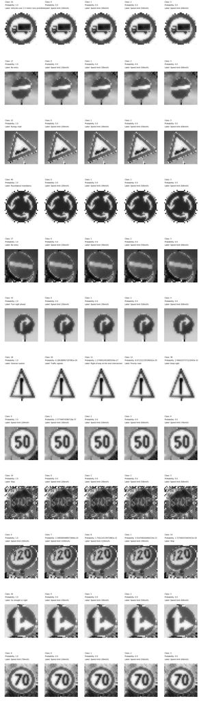

```python
### Plot the top 5 softmax probabilities, their corresponding class and class labels, for each of the new images

# initialize plot grid
plt.figure(figsize=(20, 30))

# loop through the images
for i in range(len(X_capture)):

    # top 5 softmax probabilities for the image
    top_probs = top_k.values[i]

    # corresponding class prediction for the top 5 softmax probabilities
    top_classes = top_k.indices[i]

    # loop through each prediction and plot it
    for j in range(len(top_probs)):

        # plot top 5 preditions on the same row
        plt.subplot(len(X_capture), len(top_probs), len(top_probs)*i+j+1)

        # plot the image
        plt.imshow(X_capture[i][...,0], cmap='gray')

        # print the top j predicted class, its probabilty and label
        plt.text(0, -10, "Class: {}".format(top_classes[j]), wrap=True)
        plt.text(0, -7, "Probability: {}".format(top_probs[j]), wrap=True)
        plt.text(0, -4, "Label: {}".format(labels[top_classes[j]]), wrap=True)

        # remove axis
        plt.axis('off')

# add padding to the top of each image to create room for prining results
plt.subplots_adjust(top=2)
```

### Project Writeup

Once you have completed the code implementation, document your results in a project writeup using this [template](https://github.com/udacity/CarND-Traffic-Sign-Classifier-Project/blob/master/writeup_template.md) as a guide. The writeup can be in a markdown or pdf file.